# HUDM 5026 Final Project

Simon Chen

12/15/2021

## Introduction

The PTSD Outcomes Within Each Treatment Arm dataset includes information on how PTSD was measured and at which timepoint. PTSD baseline mean score and standard deviation are provided as well as the within-treatment change from baseline. Within-group effect size is also included. The percent of participants who achieve loss of PTSD diagnosis and the percent who achieve clinically meaningful response are included for studies that reported these outcomes.  
They are categorized into six types of treatments: psychotherapy, pharmacotherapy, complementary and integrative health (CIH), nonpharmacologic biological, nonpharmacologic cognitive and collaborative care. A final category is control interventions, which are comparison conditions. I am interested in what the change is in PTSD Scale score across all study arms of a specific treatment type.  
Values abstracted as not applicable (“NA”) or not reported (“NR”) by the study are null values (empty cells).

```r
# import certain library
library(tidyverse)
```

```r
library(ggplot2)
```

```r
# Read data and import it as tibble.
dat <- read_csv("PTSD_Outcomes_Within_Each_Treatment_Arm.csv")
dat <- tibble(dat)
dat
```

```
## # A tibble: 3,737 × 77
##    study_id   `Study Class` `Treatment Focus … `Total N Random… `Intervention G…
##    <chr>      <chr>         <chr>                         <dbl> <chr>
##  1 acarturk2… Psychotherapy PTSD                             98 A
##  2 acarturk2… Psychotherapy PTSD                             98 A
##  3 acarturk2… Psychotherapy PTSD                             98 A
##  4 acarturk2… Psychotherapy PTSD                             98 B
##  5 acarturk2… Psychotherapy PTSD                             98 B
##  6 acarturk2… Psychotherapy PTSD                             98 B
##  7 acarturk2… Psychotherapy PTSD                             98 A
##  8 acarturk2… Psychotherapy PTSD                             98 A
##  9 acarturk2… Psychotherapy PTSD                             98 A
## 10 acarturk2… Psychotherapy PTSD                             98 B
## # … with 3,727 more rows, and 72 more variables:
## #   Treatment Focus (Arm level) <chr>,
## #   Treatment Focus Subclass (Arm level) <chr>,
## #   N Completed Outcome Measurement <dbl>,
## #   N Completed Outcome Measurement Detail <chr>,
## #   Publication Treatment Name <chr>, NCPTSD Treatment Name <chr>,
## #   Psychotherapy <chr>, Psychotherapy Subclass <chr>, Pharmacotherapy <chr>, …
```

## Cleaning data

Since there are too many missing data and they are irrelevant to the anlysis. So we can just drop the missing cases. I shrink the data by removingh rows with NA values from Measure Score Mean and Measure Score Standard Deviation and N compeleted OUtcome Measurement.  
The data deleted to 1774 rows.

```r
dat1 <- dat %>%
  drop_na("Measure Score Mean") %>%
  drop_na("Measure Score Standard Deviation") %>%
  drop_na("N Completed Outcome Measurement")
dat1
```

```
## # A tibble: 1,774 × 77
##    study_id   `Study Class`  `Treatment Focus… `Total N Random… `Intervention G…
##    <chr>      <chr>          <chr>                        <dbl> <chr>
##  1 acarturk2… Psychotherapy  PTSD                            98 A
##  2 acarturk2… Psychotherapy  PTSD                            98 B
##  3 acierno20… Psychotherapy  PTSD                           150 A
##  4 acierno20… Psychotherapy  PTSD                           150 B
##  5 adenauer2… Psychotherapy  PTSD                            34 A
##  6 adenauer2… Psychotherapy  PTSD                            34 A
##  7 adenauer2… Psychotherapy  PTSD                            34 B
##  8 adenauer2… Psychotherapy  PTSD                            34 B
##  9 ahmadizad… Nonpharmacolo… PTSD                            65 A
## 10 ahmadizad… Nonpharmacolo… PTSD                            65 A
## # … with 1,764 more rows, and 72 more variables:
## #   Treatment Focus (Arm level) <chr>,
## #   Treatment Focus Subclass (Arm level) <chr>,
## #   N Completed Outcome Measurement <dbl>,
## #   N Completed Outcome Measurement Detail <chr>,
## #   Publication Treatment Name <chr>, NCPTSD Treatment Name <chr>,
## #   Psychotherapy <chr>, Psychotherapy Subclass <chr>, Pharmacotherapy <chr>, …
```

We won’t use all the data categories, so I just selcted the useful data to do the analysis.

```r
dat2 <- select(dat1,
  study_id,
  "Study Class",
  'Treatment Focus (Arm level)',
  'Total N Randomized',
  "N Completed Outcome Measurement",
  "Measure Score Mean",
  "Male Percent (Study level)",
  "Year Added to PTSD-Repository"
)
dat2
```

```
## # A tibble: 1,774 × 8
##    study_id   `Study Class`  `Treatment Focus… `Total N Random… `N Completed Ou…
##    <chr>      <chr>          <chr>                        <dbl>            <dbl>
##  1 acarturk2… Psychotherapy  PTSD                            98               49
##  2 acarturk2… Psychotherapy  Control                         98               49
##  3 acierno20… Psychotherapy  PTSD                           150               68
##  4 acierno20… Psychotherapy  PTSD                           150               64
##  5 adenauer2… Psychotherapy  PTSD                            34               11
##  6 adenauer2… Psychotherapy  PTSD                            34               11
##  7 adenauer2… Psychotherapy  Control                         34                8
##  8 adenauer2… Psychotherapy  Control                         34                8
##  9 ahmadizad… Nonpharmacolo… PTSD                            65               16
## 10 ahmadizad… Nonpharmacolo… PTSD                            65               22
## # … with 1,764 more rows, and 3 more variables: Measure Score Mean <dbl>,
## #   Male Percent (Study level) <dbl>, Year Added to PTSD-Repository <dbl>
```

## Data Visualization

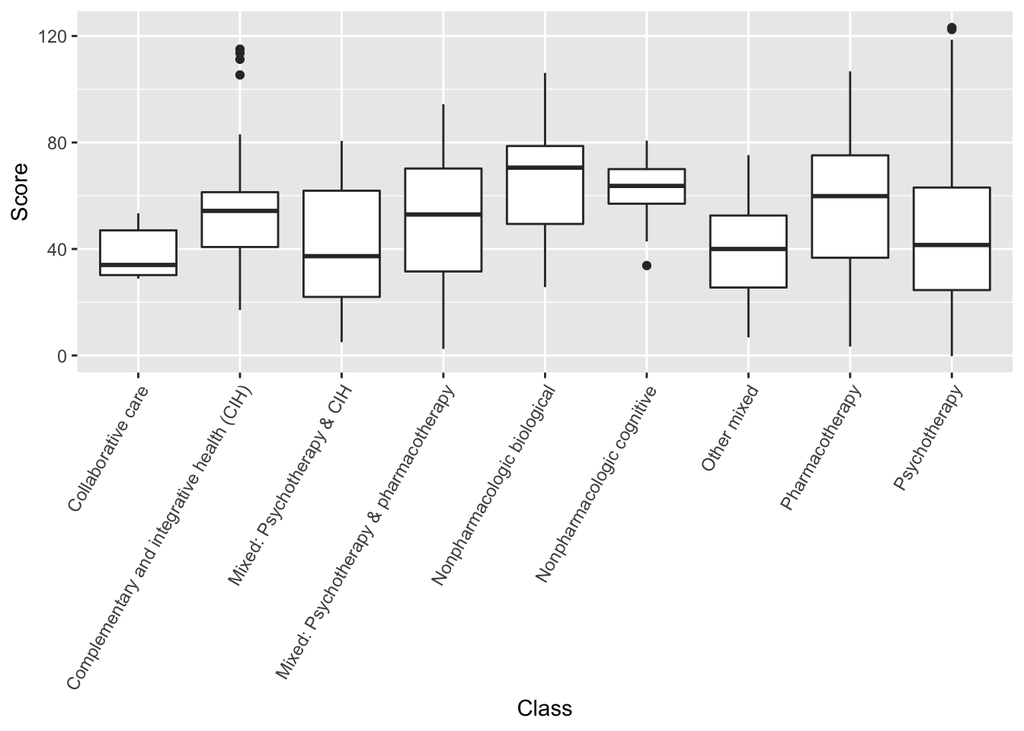

```r
names(dat2)[names(dat2) == 'Study Class'] <- 'Class'
names(dat2)[names(dat2) == 'Measure Score Mean'] <- 'Score'
ggplot(data = dat2, aes(x = Class, y = Score)) +
  geom_boxplot() +
  theme(axis.text.x = element_text(angle = 60, hjust = 1))
```

Then I want to find more about the gender issue in the PTSD treatment.

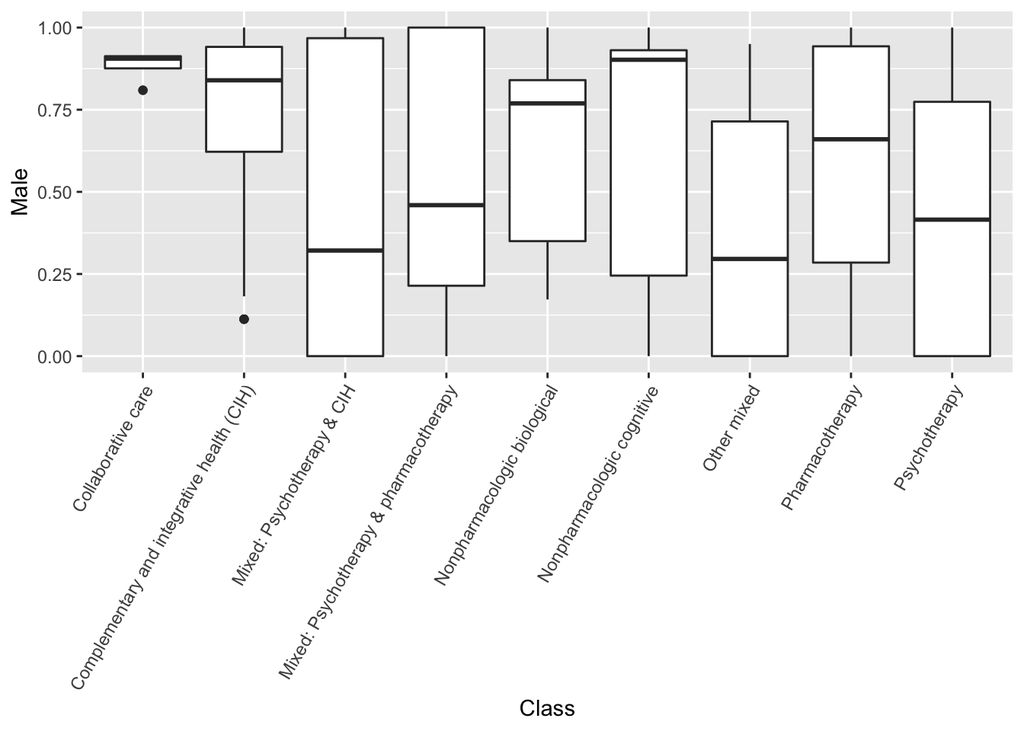

```r
names(dat2)[names(dat2) == "Male Percent (Study level)"] <- 'Male'
ggplot(data = dat2, aes(x = Class, y = Male)) +
  geom_boxplot() +
  theme(axis.text.x = element_text(angle = 60, hjust = 1))
```

As we can see, in Psychotherapy and Mixed with CIH treatment was implemented in male and female groups. Even though the score varies a lot, but the mixed treatment is generally good for both male and female group.

## Reference

Publisher National Center for PTSD. (2021, November 30). PTSD outcomes within each treatment arm. PTSD Outcomes Within Each Treatment Arm - CKAN. Retrieved December 22, 2021, from https://catalog.data.gov/dataset/ptsd-outcomes-within-each-treatment-arm